# Week 2: Regression, Rebalancing, and CS 1 Walkthrough

STAT 4170 – Financial Time Series and Forecasting

Taylor R. Brown

# Part 1: Estimating Cross-Sectional Regression Models

## The Estimation Problem

To use $\boldsymbol{\mu}$ and $\boldsymbol{\Sigma}$ in practice, we need to **estimate** them from data.

The simplest approach: use the sample mean and sample covariance of historical returns. We’ll discover what the drawbacks are from this approach in our case study.

Another approach (maybe the most common): **cross-sectional regression models** like CAPM.

## The Estimation Problem

CAPM stands for the “Capital Asset Pricing Model”

CAPM says that each asset’s return is a linear function of one or more **common factors**.

This gives us more “efficient” estimates, especially when $k$ is large relative to the sample size $n$. We’ll talk more about this in our case study.

## The Estimation Problem

From a data scientist’s perspective, it’s just simple linear regression and parameter reduction.

From a finance person’s perspective, it’s basically gospel. They really use these “factor models” for a lot of the statistical modeling. It’s very common to run cross sectional regressions and call them “factor models.”

For the financial justification—equilibrium arguments, the market portfolio, and the derivation of the CAPM pricing equation—see Campbell (2018), ch. 3.

## CAPM: The Simple Version

The **Capital Asset Pricing Model** says:<sup>1</sup>

$$y_{t,i} = \alpha_i + \beta_i \cdot r_{t,\text{SPY}} + \epsilon_{t,i}$$

- $r_{t,\text{SPY}}$: the “market return” (e.g. for S&P 500) at time $t$
- $\beta_i$: asset $i$’s sensitivity to the market (“beta”)
- $\alpha_i$: excess return not explained by the market (“alpha”)
- $\epsilon_{t,i}$: idiosyncratic noise, $\mathbb{E}[\epsilon_{t,i}] = 0$
- This is not a forecasting model! It’s not trying to forecast the future with historical data.
[^1]: Some references write CAPM in terms of **excess returns** (returns minus the risk-free rate $r_f$): $y_{t,i} - r_{f,t} = \alpha_i + \beta_i (r_{t,\text{SPY}} - r_{f,t}) + \epsilon_{t,i}$. We’ll use raw returns here for simplicity.

## CAPM: Taking the Mean of Both Sides

Apply $\mathbb{E}[\cdot \mid \text{past}]$ to both sides of the CAPM equation, using $\mathbb{E}[\epsilon_{t,i}] = 0$:

$$\mathbb{E}[y_{t,i}] = \alpha_i + \beta_i \, \mathbb{E}[r_{t,\text{SPY}}] + \mathbb{E}[\epsilon_{t,i}]$$

$$\mu_i = \alpha_i + \beta_i \, \mu_{\text{SPY}}$$

- Asset $i$’s expected return is a linear function of the market’s expected return.
- $\alpha_i$ shifts the line up or down; $\beta_i$ sets its slope.

## CAPM: Taking the Variance of Both Sides

Apply $\mathbb{V}[\cdot]$ to both sides, assuming $\epsilon_{t,i}$ is uncorrelated with $r_{t,\text{SPY}}$:

$$\mathbb{V}[y_{t,i}] = \beta_i^2 \, \mathbb{V}[r_{t,\text{SPY}}] + \mathbb{V}[\epsilon_{t,i}]$$

$$\sigma_i^2 = \beta_i^2 \, \sigma_{\text{SPY}}^2 + \sigma_{\epsilon_i}^2$$

- **Systematic risk** $\beta_i^2 \sigma_{\text{SPY}}^2$: risk coming from the market, scaled by $\beta_i^2$.
- **Idiosyncratic risk** $\sigma_{\epsilon_i}^2$: risk specific to asset $i$, unrelated to the market.
- A high-beta fund/stock/investment amplifies market moves (large systematic-risk contribution). A low-beta stock is more insulated from market swings.

## CAPM: Fitting One Asset

Should you YOLO tech stocks, or stick to more conservative investments?

```python
import pandas as pd, numpy as np
import statsmodels.api as sm

data = pd.read_csv("../data/prices.csv", index_col=0, parse_dates=True)
rets = data[["XLK", "SPY"]].pct_change().dropna() * 100

y   = rets["XLK"].values
x   = sm.add_constant(rets["SPY"].values)

mod = sm.OLS(y, x).fit()
print(mod.summary())
```

```
                            OLS Regression Results
==============================================================================
Dep. Variable:                      y   R-squared:                       0.870
Model:                            OLS   Adj. R-squared:                  0.870
Method:                 Least Squares   F-statistic:                     8364.
Date:                Thu, 29 Oct 2026   Prob (F-statistic):               0.00
Time:                        18:48:52   Log-Likelihood:                -1213.4
No. Observations:                1256   AIC:                             2431.
Df Residuals:                    1254   BIC:                             2441.
Df Model:                           1
Covariance Type:            nonrobust
==============================================================================
                 coef    std err          t      P>|t|      [0.025      0.975]
------------------------------------------------------------------------------
const          0.0154      0.018      0.855      0.392      -0.020       0.051
x1             1.2415      0.014     91.456      0.000       1.215       1.268
==============================================================================
Omnibus:                       40.837   Durbin-Watson:                   1.963
Prob(Omnibus):                  0.000   Jarque-Bera (JB):              104.168
Skew:                           0.021   Prob(JB):                     2.40e-23
Kurtosis:                       4.410   Cond. No.                         1.33
==============================================================================

Notes:
[1] Standard Errors assume that the covariance matrix of the errors is correctly specified.
```

The estimated $\hat{\beta}$ tells us: for every 1% the market moves, XLK moves roughly $\hat{\beta}$%.

## From One Asset to Many: One Row

For a single time period $t$, the CAPM equation for all $m$ assets at once is just $m$ separate regressions sharing the same $\mathbf{x}_t$:

$$\underbrace{\begin{bmatrix} y_{t,1} & y_{t,2} & \cdots & y_{t,m} \end{bmatrix}}_{\text{row } t \text{ of } \mathbf{Y}}
=
\underbrace{\begin{bmatrix} 1 & r_{t,\text{SPY}} \end{bmatrix}}_{\text{row } t \text{ of } \mathbf{X}}
\underbrace{\begin{bmatrix} \alpha_1 & \alpha_2 & \cdots & \alpha_m \\ \beta_1 & \beta_2 & \cdots & \beta_m \end{bmatrix}}_{\mathbf{B}}
+
\underbrace{\begin{bmatrix} \epsilon_{t,1} & \epsilon_{t,2} & \cdots & \epsilon_{t,m} \end{bmatrix}}_{\text{row } t \text{ of } \mathbf{E}}$$

Each column of $\mathbf{B}$ is one asset’s $(\alpha_i, \beta_i)^\intercal$. Stack $n$ such rows and you get the full matrix equation.

## From One Asset to a Portfolio: Multivariate Regression

When we have $m$ assets to model simultaneously, we stack them into a matrix:

$$\underbrace{\begin{bmatrix}
y_{1,1} & \cdots & y_{1,m} \\
y_{2,1} & \cdots & y_{2,m} \\
\vdots & & \vdots \\
y_{n,1} & \cdots & y_{n,m}
\end{bmatrix}}_{\mathbf{Y},\; n \times m}
=
\underbrace{\begin{bmatrix}
1 & r_{1,\text{SPY}} \\
1 & r_{2,\text{SPY}} \\
\vdots & \vdots \\
1 & r_{n,\text{SPY}}
\end{bmatrix}}_{\mathbf{X},\; n \times (r+1)}
\underbrace{\begin{bmatrix} \alpha_1 & \cdots & \alpha_m \\ \beta_1 & \cdots & \beta_m \end{bmatrix}}_{\mathbf{B},\; (r+1) \times m}
+
\underbrace{\begin{bmatrix}
\epsilon_{1,1} & \cdots & \epsilon_{1,m} \\
\epsilon_{2,1} & \cdots & \epsilon_{2,m} \\
\vdots & & \vdots \\
\epsilon_{n,1} & \cdots & \epsilon_{n,m}
\end{bmatrix}}_{\mathbf{E},\; n \times m}$$

$$\underbrace{\mathbf{Y}}_{n \times m}
=
\underbrace{\mathbf{X}}_{n \times (r+1)}
\underbrace{\mathbf{B}}_{(r+1) \times m}
+
\underbrace{\mathbf{E}}_{n \times m}$$

where row $t$ of $\mathbf{Y}$ is $\mathbf{y}_t^\intercal$, row $t$ of $\mathbf{X}$ is $\mathbf{x}_t^\intercal$ (the factor values at time $t$).

Regarding the errors, rows are completely independent from one another, but within a row, $\text{Cov}(\boldsymbol{\epsilon}_t) = \boldsymbol{\Sigma}_y$.

## Estimating B and $\Sigma_y$

Because the same predictors appear in every column of $\mathbf{Y}$, we can estimate $\mathbf{B}$ column by column using OLS:

$$\hat{\mathbf{B}} = (\mathbf{X}^\intercal \mathbf{X})^{-1} \mathbf{X}^\intercal \mathbf{Y}$$

The residual covariance is then:

$$\hat{\boldsymbol{\Sigma}}_y = \frac{1}{n}(\mathbf{Y} - \mathbf{X}\hat{\mathbf{B}})^\intercal (\mathbf{Y} - \mathbf{X}\hat{\mathbf{B}})$$

```python
# Multivariate OLS: same X for all m dependent variables
B_hat = np.linalg.lstsq(X, Y, rcond=None)[0]   # (r+1, m)
resids = Y - X @ B_hat                           # (n, m)
Sigma_hat = resids.T @ resids / len(resids)      # (m, m)
```

# Part 2: From Regression Output to Forecast Moments

## From Regression to Forecast Moments

Given estimates $\hat{\mathbf{B}}$ and $\hat{\boldsymbol{\Sigma}}_y$, what are $\boldsymbol{\mu}$ and $\boldsymbol{\Sigma}$?

The **law of total expectation** says that if our regression model is true, then

$$\mathbb{E}[\mathbf{y}_{t+1} \mid \text{past}] = \mathbb{E}\!\left[\mathbb{E}[\mathbf{y}_{t+1} \mid \mathbf{x}_{t+1}]\mid \text{past}\right] = \mathbb{E}[\mathbf{B}^\intercal \mathbf{x}_{t+1}\mid \text{past}] = \mathbf{B}^\intercal \mathbb{E}[\mathbf{x}_{t+1}\mid \text{past}]$$

Plug in whatever estimate for $\mathbb{E}[\mathbf{x}_{t+1}\mid \text{past}]$ you want, but the simplest is the historical average:

$$\boldsymbol{\mu} \approx \hat{\mathbf{B}}^\intercal \bar{\mathbf{x}}$$

Our next unit on time series models will be helpful for this, too!

## From Regression to Forecast Moments

The **law of total (co)variance** says

$$\mathbb{V}[\mathbf{y}_{t+1} \mid \text{past}] = \mathbb{V}[\mathbb{E}[\mathbf{y}_{t+1}\mid\mathbf{x}_{t+1}]\mid \text{past}] + \mathbb{E}[\mathbb{V}[\mathbf{y}_{t+1}\mid\mathbf{x}_{t+1}]\mid \text{past}]$$
,

With our model estimates:

$$\mathbb{V}[\mathbf{y}_{t+1} \mid \text{past}] \approx \hat{\mathbf{B}}^\intercal \hat{\boldsymbol{\Sigma}}_X \hat{\mathbf{B}} + \hat{\boldsymbol{\Sigma}}_y$$

- $\hat{\boldsymbol{\Sigma}}_X$ is some estimate of **future factor** covariance (e.g. historical covariance matrix)
- $\hat{\mathbf{B}}^\intercal \hat{\boldsymbol{\Sigma}}_X \hat{\mathbf{B}}$: variance coming from uncertainty in the **factor** (shared across all assets)
- $\hat{\boldsymbol{\Sigma}}_y$: **idiosyncratic** variance, the part no factor explains

## Full CAPM Example in Python

```python
import pandas as pd, numpy as np
import statsmodels.api as sm

sectors = ["XLC","XLY","XLP","XLE","XLF","XLV","XLI","XLB","XLRE","XLK","XLU"]

data = pd.read_csv("../data/prices.csv", index_col=0, parse_dates=True)
rets = data[sectors + ["SPY"]].pct_change().dropna() * 100

Y = rets[sectors].values           # (n, 11)
X = sm.add_constant(rets["SPY"].values)  # (n, 2)

B_hat   = np.linalg.lstsq(X, Y, rcond=None)[0]   # (2, 11)
resids  = Y - X @ B_hat
Sigma_y = resids.T @ resids / len(resids)

x_bar = X.mean(axis=0)            # (2,) — average [1, SPY_return]
m_vec = B_hat.T @ x_bar           # (11,) forecast mean vector

Sigma_X = np.cov(X.T)             # (2, 2)
S_mat   = B_hat.T @ Sigma_X @ B_hat + Sigma_y   # (11, 11) forecast cov
```

## Special Case: Intercept Only

If we use $\mathbf{x}_t^\intercal = \begin{bmatrix} 1 \end{bmatrix}$ (no factors, just an intercept), then:

$$\hat{\mathbf{B}} = \bar{\mathbf{Y}}^\intercal \quad \Rightarrow \quad \boldsymbol{\mu} \approx \bar{Y}$$

and

$$\mathbb{V}[\mathbf{y}_{t+1} \mid \text{past}] \approx \hat{\boldsymbol{\Sigma}}_y = \frac{1}{n}(\mathbf{Y} - \bar{\mathbf{Y}})^\intercal(\mathbf{Y} - \bar{\mathbf{Y}})$$

This is exactly the **sample mean** and **sample covariance**. The CAPM regression is a structured way to get better estimates when factor structure is present.

# Part 3: From Forecast Moments to Portfolio Weights

## The Optimization Problem

We now have estimates of $\boldsymbol{\mu}$ and $\boldsymbol{\Sigma}$. We also have control over over $\mathbf{w}$. How should we choose it?

We’ll we have to balance risk and reward!

- reward: $\mathbf{w}^\intercal \boldsymbol{\mu}$
- risk: $\mathbf{w}^\intercal \boldsymbol{\Sigma} \mathbf{w}$

## The Optimization Problem

- reward: $\mathbf{w}^\intercal\boldsymbol{\mu}$
- risk: $\mathbf{w}^\intercal \boldsymbol{\Sigma} \mathbf{w}$

We need to “combine” them into one “goodness/satisfaction” number. Twiddle $\mathbf{w}$ to maximize $U(\mathbf{w})$.

Unfortunately, different investors have different risk tolerances, so there is no single “right” answer.

## The Optimization Problem

We parameterize preferences with **risk aversion** $\gamma > 0$ and maximize:

$$U(\mathbf{w}) = \mathbf{w}^\intercal \boldsymbol{\mu} - \frac{1}{2}\gamma \, \mathbf{w}^\intercal \boldsymbol{\Sigma} \mathbf{w}$$

There’s also a **constraint**.

Maximize this **subject to $\mathbf{1}^\intercal \mathbf{w} = 1$.**

Sometimes the constraint is written $g(\mathbf{w}) = 0$.

In this case, $g(\mathbf{w}) = \mathbf{1}^\intercal \mathbf{w} - 1$

## The Optimization Problem

$$U(\mathbf{w}) = \mathbf{w}^\intercal \boldsymbol{\mu} - \frac{1}{2}\gamma \, \mathbf{w}^\intercal \boldsymbol{\Sigma} \mathbf{w}$$

- Large $\gamma$: investor strongly penalizes variance → conservative portfolio
- Small $\gamma$: investor chases return → aggressive portfolio
- Don’t memorize rules of thumb. Try a few. Data scale dependent.

This is the **mean-variance utility** from Markowitz (1952). For a broader discussion of utility functions, risk aversion coefficients, and the expected utility framework that motivates this form, see Campbell (2018), ch. 1. For worked examples in small-dimensional settings (one risky + one riskless asset, two risky assets), see Campbell (2018), ch. 2.

## The Risk-Return Tradeoff

Before solving, let’s visualize: for random weights, what (risk, return) pairs are achievable?

There is a clear frontier — the **efficient frontier** — that we can trace out analytically.

```python
import matplotlib.pyplot as plt

k    = len(m_vec)
n_w  = 2000
W    = np.random.dirichlet(np.ones(k)/k, n_w)  # uniform on the simplex, sum-to-1

all_means = W @ m_vec
all_sds   = np.sqrt(np.einsum("ij,jk,ik->i", W, S_mat, W))

plt.scatter(all_sds, all_means, alpha=0.3, s=5)
plt.xlabel("Std. deviation (risk)")
plt.ylabel("Expected return")
plt.tight_layout()
plt.show()
```

## The Risk-Return Tradeoff

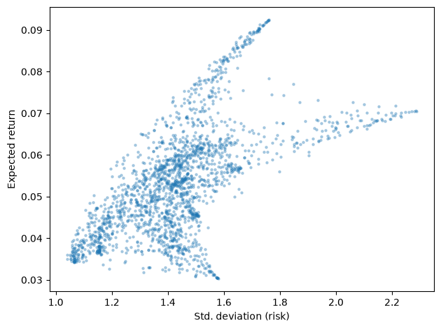

## Lagrange Multipliers: The Objective

For two assets we can draw $U(w_1, w_2)$ as contours. The unconstrained maximum is the center of the ellipses.

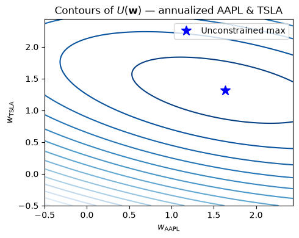

## Lagrange Multipliers: Adding the Constraint

The constraint $w_1 + w_2 = 1$ is a line. The constrained optimum is where the line is **tangent to a contour** — meaning $\nabla U$ and $\nabla g$ point in the same direction

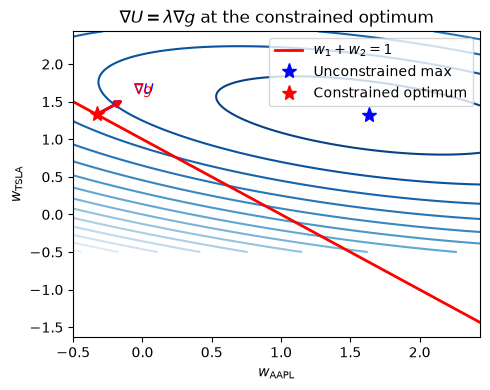

## Lagrange Multipliers

At the optimum, $\nabla U = \lambda \nabla g$, i.e.

$$\nabla U(\mathbf{w}) - \lambda \, \nabla g(\mathbf{w}) = \mathbf{0}$$

But this is exactly the critical condition for the **unconstrained** problem of maximizing

$$\mathcal{L}(\mathbf{w}, \lambda) = U(\mathbf{w}) - \lambda \, g(\mathbf{w})
= \mathbf{w}^\intercal \boldsymbol{\mu} - \frac{1}{2}\gamma \, \mathbf{w}^\intercal \boldsymbol{\Sigma} \mathbf{w} - \lambda(\mathbf{1}^\intercal \mathbf{w} - 1)$$

since $\frac{\partial \mathcal{L}}{\partial \mathbf{w}} = \nabla U - \lambda \nabla g = \mathbf{0}$ and $\frac{\partial \mathcal{L}}{\partial \lambda} = -(g(\mathbf{w}) - 0) = 0$ enforces the constraint.

we call $\mathcal{L}(\mathbf{w}, \lambda)$ **the Lagrangian**

## Solving with Lagrange Multipliers

To maximize $U(\mathbf{w})$ subject to $\mathbf{1}^\intercal \mathbf{w} = 1$, form the **Lagrangian**:

$$\mathcal{L}(\mathbf{w}, \lambda) = \underbrace{\mathbf{w}^\intercal \boldsymbol{\mu} - \frac{1}{2}\gamma \, \mathbf{w}^\intercal \boldsymbol{\Sigma} \mathbf{w}}_{U(\mathbf{w})} - \lambda \underbrace{(\mathbf{1}^\intercal \mathbf{w} - 1)}_{g(\mathbf{w})}$$

Set partial derivatives to zero:

$$\frac{\partial \mathcal{L}}{\partial \mathbf{w}} = \boldsymbol{\mu} - \gamma \boldsymbol{\Sigma} \mathbf{w} - \lambda \mathbf{1} = \mathbf{0} \tag{1}$$

$$\frac{\partial \mathcal{L}}{\partial \lambda} = 1 - \mathbf{1}^\intercal \mathbf{w} = 0 \tag{2}$$

## Solving for $\mathbf{w}^*$

From equation (1):

$$\mathbf{w}^* = \frac{1}{\gamma} \boldsymbol{\Sigma}^{-1}(\boldsymbol{\mu} - \lambda \mathbf{1}) \tag{3}$$

Substitute into equation (2) and solve for $\lambda$:

$$\lambda = \frac{\mathbf{1}^\intercal \boldsymbol{\Sigma}^{-1} \boldsymbol{\mu} - \gamma}{\mathbf{1}^\intercal \boldsymbol{\Sigma}^{-1} \mathbf{1}} \tag{4}$$

Substitute (4) back into (3):

$$\mathbf{w}^* = \frac{1}{\gamma} \boldsymbol{\Sigma}^{-1} \left[ \boldsymbol{\mu} - \frac{\mathbf{1}^\intercal \boldsymbol{\Sigma}^{-1}\boldsymbol{\mu} - \gamma}{\mathbf{1}^\intercal \boldsymbol{\Sigma}^{-1}\mathbf{1}} \mathbf{1} \right]$$

## Optimal Weights in Python

```python
def mpt_weights(mu, Sigma, gamma, s=1.0):
    Sinv  = np.linalg.inv(Sigma)
    ones  = np.ones(len(mu))
    q1    = ones @ Sinv @ mu
    q2    = ones @ Sinv @ ones
    lam   = (q1 - gamma * s) / q2
    return Sinv @ (mu - lam * ones) / gamma


w_star = mpt_weights(m_vec, S_mat, gamma=1.0)
print("Optimal weights:", w_star.round(4))
print("Expected return:", w_star @ m_vec)
print("Std. deviation :", np.sqrt(w_star @ S_mat @ w_star))
```

```
Optimal weights: [ 0.2097  0.1125  0.7317  0.0506 -0.231   0.4318  0.1562 -0.0384 -0.1533
 -0.223  -0.0467]
Expected return: 0.031085353449810085
Std. deviation : 0.9876008040079656
```

## The Efficient Frontier

As we vary $\gamma$ from $\infty$ (minimum variance) down toward $0$ (maximum return), we trace the **efficient frontier** — the set of portfolios that are optimal for *some* risk aversion.

```python
gammas = np.logspace(-6, 6, 2000)

opt_means = np.array([mpt_weights(m_vec, S_mat, g) @ m_vec for g in gammas])
opt_sds   = np.array([np.sqrt(mpt_weights(m_vec, S_mat, g) @ S_mat @ mpt_weights(m_vec, S_mat, g)) for g in gammas])

# clip frontier to the scatter's range so neither drowns the other
sd_max  = np.percentile(all_sds,   99) * 1.2
mu_max  = np.percentile(all_means, 99) * 1.3
mu_min  = np.percentile(all_means,  1) - abs(np.percentile(all_means, 1)) * 0.2
mask    = (opt_sds <= sd_max) & (opt_means <= mu_max) & (opt_means >= mu_min)

plt.scatter(all_sds, all_means, alpha=0.2, s=5, label="Random portfolios")
plt.plot(opt_sds[mask], opt_means[mask], color="red", linewidth=2, label="Efficient frontier")
plt.xlim(0, sd_max)
plt.ylim(mu_min, mu_max)
plt.xlabel("Std. deviation (risk)")
plt.ylabel("Expected return")
plt.legend()
plt.tight_layout()
plt.show()
```

## The Efficient Frontier

Ignoring uncertainty of parameter estimates…

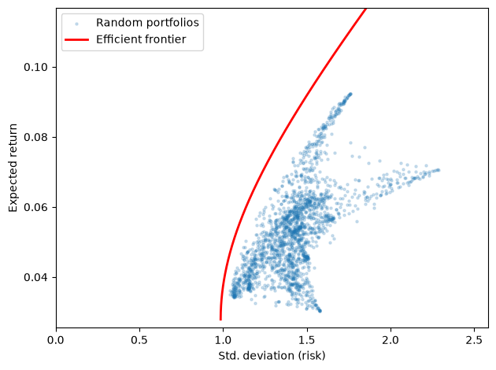

## Key Takeaways

1. **A portfolio’s return is $\mathbf{w}^\intercal \mathbf{y}_{t+1}$**, a scalar formed by weighting $k$ assets.
2. **The first two moments** of the forecast distribution — $\boldsymbol{\mu}$ (mean vector) and $\boldsymbol{\Sigma}$ (covariance matrix) — are sufficient for mean-variance analysis.
3. **Cross-sectional regression** (CAPM) gives a structured way to estimate $\boldsymbol{\mu}$ and $\boldsymbol{\Sigma}$ by decomposing returns into a factor component and idiosyncratic noise.
4. **MPT** turns the estimation problem into an optimization: given $\boldsymbol{\mu}$ and $\boldsymbol{\Sigma}$, the closed-form optimal weights $\mathbf{w}^*$ maximize mean-variance utility for a given risk aversion $\gamma$.
5. Sweeping over $\gamma$ traces the **efficient frontier** — the set of portfolios that minimize variance for a given expected return.

## Looking Ahead

Now you have all the information you need to finish **Case Study 1**!

## References

- Markowitz, H. (1952). *Portfolio selection*. Journal of Finance.
- Campbell, J. Y. (2018). *Financial Decisions and Markets*. Princeton University Press.
- López de Prado, M. (2018). *Advances in Financial Machine Learning*. Wiley.
- Johnson, R. A. & Wichern, D. W. *Applied Multivariate Statistical Analysis*, ch. 7.7.